# 390R Homework 3

**Due: Tuesday, November 1 at 2:30 pm**

**Instructions**  
- Late submission is not allowed.  
- All answers should be typed up using Rmarkdown and submitted as an html file, with an Rmarkdown file. There will be a penalty on irreproducible submissions.  
- The points of optional questions will add to the total score (up to the maximum score). There is no penalty on incorrect answers to the optional questions.  
- Your are allowed to discuss the problem set with those who are part of this class (i.e., other students who are currently taking this course, the teaching assistant, and the instructor). However, you must write up answers (including computer code) on your own. Under no circumstances may students copy each other’s answer.

# 1 Health Savings experiments

We did some analysis for the rosca dataset in class. Let’s do more. Please download the dataset rosca.csv from Moodle and import it into RStudio:

```r
rosca <-  read.csv("directory of dataset")
```

In the `read.csv` function above, you need to enter the diretory of the data file on your own computer. For MAC users, you can drag the file to the terminal to get the directory; for Windows users, go to the folder that contains the file, click at the end of the box that has the directory like “user> name> xxx> xxxx>”. This highlights the full path to the folder.

We need to make some changes to the data.

```r
rosca$treatment <- NA
rosca$treatment[rosca$encouragement == 1] <- "control"
rosca$treatment[rosca$safe_box == 1] <- "safebox"
rosca$treatment[rosca$locked_box == 1] <- "lockbox"
rosca$treatment <- as.factor(rosca$treatment)
rosca <-  rosca[rosca$has_followup2 == 1, ]
rosca$bg_female <-  factor(rosca$bg_female )
rosca$bg_married <-  factor(rosca$bg_married)
```

Description of this dataset can be found in ggplot exercise on Moodle.

1. Use a bar chart to show the distribution of bg_married within each treatment condition. Which treatment condition has the highest proportion of married people? (Note: you need to add appropriate title, labels of axes, lengend name, and change the names of the two levels in the legend.)
2. The barplots do not contain the exact numbers or proportions so we can add them to make the figure more informative. Make the following plot. Use geom_text to add the percentage for each bar (You don’t need to be perfect for the position of the annotation). The following codes calculate the counts and proportions of unmarried people under control, married people under control, unmarried people under lockbox, married people under lockbox, unmarried people under safebox, and married people under safebox. You need to change the proportions to the percentages. (You can use other methods for this. Check function percent() in scales package )

```r
y <- as.numeric(t(table(rosca$treatment,rosca$bg_married)))
prop <- table(rosca$treatment,rosca$bg_married)/length(rosca$treatment)
prop <- as.numeric(t(prop))
```

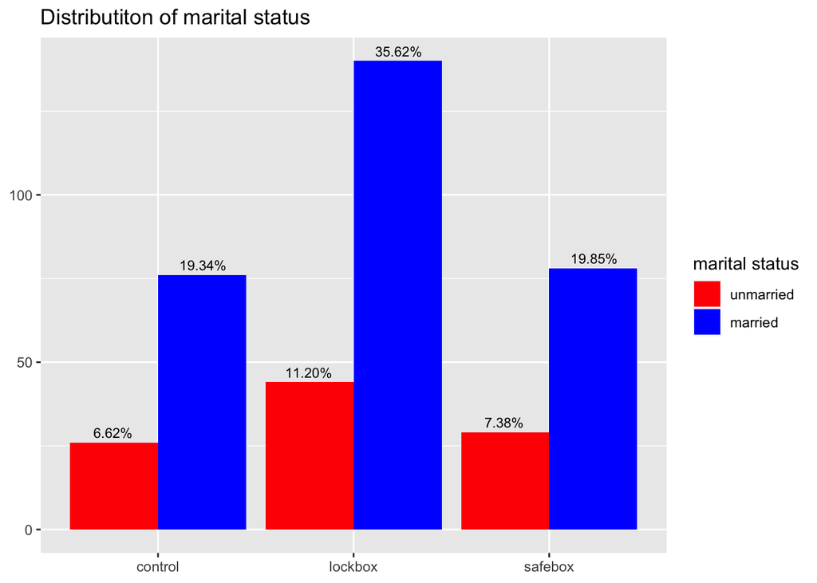

# 2 Histograms of temperature

In Problem set 2, we plotted the histograms for the 12 months in the `weather` data. In this problem, we make some tweaks to improve the figure. Let’s first add a code chunk with the following codes to remove the observations with missing data.

```r
weather <- weather %>% filter(!is.na(temp))
```

We will work on the following faceted histrograms.

```r
temp.facet <- ggplot(data = weather)+
  geom_histogram(mapping = aes(x = temp),color= "white",binwidth = 5)+
  facet_wrap(~month,nrow=4)
```

1. Add appropriate title and labels of axes. Remove the y-axis ticks and tick labels (200,400…)
2. Change the facet labels from numeric month to month abbreviations, e.g., 1 to Jan.

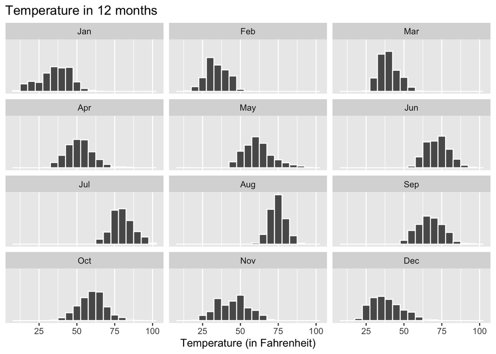

3. We can add the average termperature for each month to make the firgure more informative. Make the following plot. You can use `round(tapply(weather$temp, factor(weather$month),mean))` to obtain the average temperature of each month.

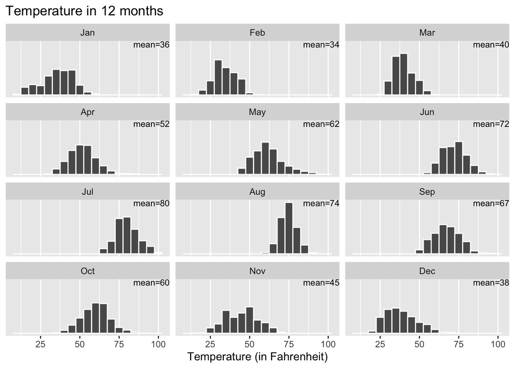

# 3 Boxplots of temperature

In problem set 2, we have a boxplot of temp split by month. We can make several changes to make the plot better.

```r
ggplot(data = weather, mapping = aes(x= factor(month),y = temp)) +
  geom_boxplot()
```

1. Remove the x-axis label, and change the tick labels from numeric month to month abbreviation as in the following plot.

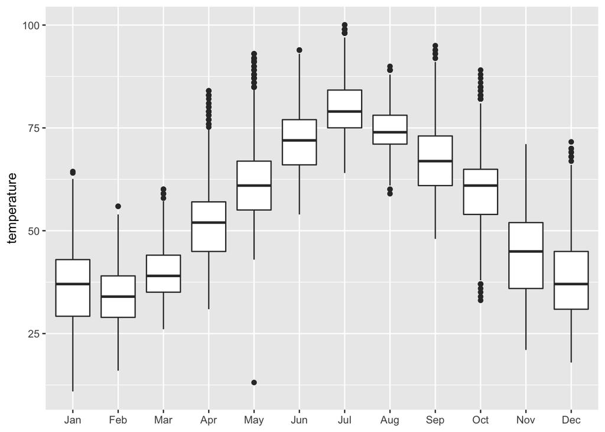

2. Remove the y-axis label, and change the tick labels on the y-axis as in the following plot.

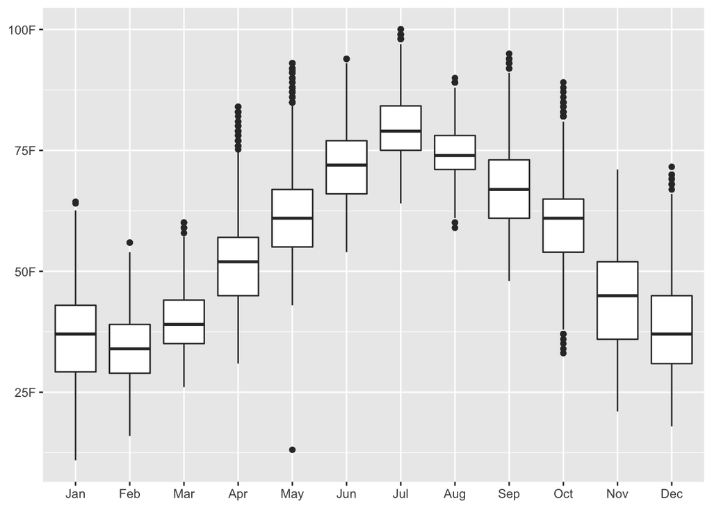

3. (optional) We can make it better by adding the degree symbol. Make the following plot.

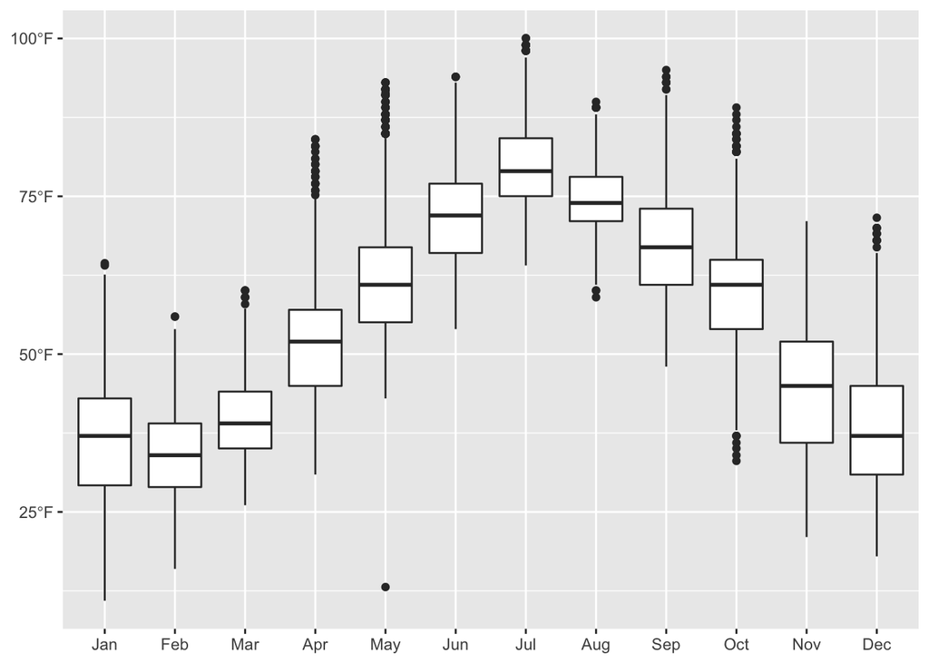